# Лабораторная работа

Рева Дарья

17 декабря 2017 г

## Загрузка пакетов

Для загрузки пакетов используются функции library и require. library (package) и require (package) загружают пакеты. require предназначен для использования внутри других функций; он возвращает FALSE и дает предупреждение (а не ошибку, как это делает library() по умолчанию), если пакет не существует. Обе функции проверяют и обновляют список подключенных в настоящее время пакетов и не перезагружают уже загруженное пространство имен.  
Пакет Matrix требуется для использования системных функций работы с матрицам; ggplot2 требуется для построения графиков.

```r
library(Matrix)
require(ggplot2)
```

## Задание 1

На выходе получаем data.frame

```r
X<-read.table(file = "bi_9.txt", sep = "\t")
#преобразуем в матрицу
X<-as.matrix(X)
```

Первый стобец цифр в таблице ниже - это номера строк в $X$, не является столбцом $X$.

**Подготовка матрицы**  
Последний признак - качество заемщика - является качественным, а не количественным, несмотря на то, что представлен в числовом виде (1,0). Перед анализом этот признак необходимо удалить из данных. Удаляем 7 столбец из таблицы данных.

```r
X<-X[,-7]
X
```

```
##       V1 V2    V3 V4    V5     V6
##  [1,] 25  0 25700  1 23000 241000
##  [2,] 31  1 27400  4 26000 265000
##  [3,] 38  2 24300  9 24000 242000
##  [4,] 35  2 23700  7 23000 231000
##  [5,] 42  2 25300 11 26000 256000
##  [6,] 48  4 37500 14 39000 385000
##  [7,] 37  2 33000  7 33000 328000
##  [8,] 42  3 34400 10 35000 348000
##  [9,] 40  2 31300  9 31000 314000
## [10,] 46  2 13300 14 14000 139000
## [11,] 33  2 35400  5 34000 348000
## [12,] 42  1  1500 12  2000  15000
## [13,] 30  1 31200  4 30000 302000
## [14,] 37  2 29700  8 29000 295000
```

[output cut: 30 more lines]

Все признаки оцениваются по разным шкалам (доход в рублях в месяц, кредит в тысячах рублей и так далее). Поэтому матрицу надо стандартизировать (выполнить центрирование и нормировку).

- $X$ - матрица, которая будет преобразована
- scale = F - значение scale определяет, как выполняется масштабирование столбцов (после центрирования). Если scale - числовой вектор с длиной, равной числу столбцов матрицы, то каждый столбец матрицы делится на соответствующее значение из scale. Если scale = FALSE, масштабирование не производится.

```r
Y<-scale(X, scale = F)
```

**Нормировка**  
Нормировка преобразует матрицу $Y$ в матрицу $Z$, в которой Евклидова норма каждого столбца равна 1. Каждый элемент матрицы $Y$ делится на Евклидову норму этого столбца.  
Функция apply используется в случаях, когда необходимо применить какую-либо функцию ко всем строкам или столбцам матрицы. В скобках указывается:

- Y - матрица, которая будет преобразована
- 2 - функция будет применена к столбцам
- norm - нормирование
- type = “2” - Евклидова норма

```r
y_norm<-apply(Y, 2, norm, type = "2")
```

- Y - матрица, которая будет преобразована
- center = F - значение center определяет, как выполняется центрирование столбцов. Если center - это числовой вектор с длиной, равной числу столбцов матрицы, то каждый столбец матрицы имеет соответствующее значение center, вычитаемого из него. Если center = TRUE, то центрирование выполняется путем вычитания значения столбца матрицы из соответствующих столбцов, а если center = FALSE, центрирование не выполняется.

```r
Z<-scale(Y, center = F, scale = y_norm)
```

## Задание 2

**Вычислить ранг матрицы $Z$, сделать соответствующие выводы.**

```r
rankMatrix(Z)[1]
```

```
## [1] 6
```

Ранг матрицы равен 6, как и количество столбцов матрицы. Следовательно, в матрице все столбцы линейно-независимые, все собственные значения будут ненулевыми.

## Задание 3

**Создать матрицы $Z \cdot Z^T$ и $Z^T \cdot Z$ , найти матрицы $U$, $V$ и $S$.**

```r
M<-Z%*%t(Z)
M1<-t(Z)%*%Z
U<-eigen(M) #44*44
V<-eigen(M1) #6*6
U$values[1:6] == V$values
```

```
## [1]  TRUE FALSE FALSE FALSE FALSE FALSE
```

```r
round(U$values[1:6]) == round(V$values)
```

```
## [1] TRUE TRUE TRUE TRUE TRUE TRUE
```

```r
round(U$values[7:44]) == 0
```

```
##  [1] TRUE TRUE TRUE TRUE TRUE TRUE TRUE TRUE TRUE TRUE TRUE TRUE TRUE TRUE
## [15] TRUE TRUE TRUE TRUE TRUE TRUE TRUE TRUE TRUE TRUE TRUE TRUE TRUE TRUE
## [29] TRUE TRUE TRUE TRUE TRUE TRUE TRUE TRUE TRUE TRUE
```

Так как минимальное значение числа столбцов и числа строк матрицы $Z$ равно 6, нет смысла хранить лишние собственные векторы матрицы $U$ .

```r
S<-V$value
S<-round(S, 10)
S<-sqrt(S)
S<-diag(S)
U<-U$vectors[ ,1:6]
V<-V$vectors
```

Попробуем восстановить исходную матрицу $Z$.

```r
Z_reconstructed1<-U%*%S%*%t(V)
identical(round(Z, 10), round(Z_reconstructed1, 10))
```

```
## [1] FALSE
```

Не удалось, так как собственные векторы вычисляются с точностью до знака. И в теореме утверждается о существовании такого разложения. Но подходящие для него собственные векторы еще нужно найти.

## Задание 4

**Выполнить SVD разложение матрицы $Z$, используя функцию svd(). Сравнить с результатами из пункта 3.**

```r
Z_svd<-svd(Z)
U_svd<-Z_svd$u
V_svd<-Z_svd$v
S_svd<-diag(Z_svd$d)
Z_reconstructed<-U_svd%*%S_svd%*%t(V_svd)

identical(Z, Z_reconstructed)
```

```
## [1] FALSE
```

```r
identical(round(Z, 10), round(Z_reconstructed, 10))
```

```
## [1] FALSE
```

FALSE, так как у объектов $Z$ и $Z reconstructed$ разные структуры. У матрицы $Z$ есть атрибуты, у $Z reconstructed$ - нет.

```r
str(Z)
```

```
##  num [1:44, 1:6] -0.2893 -0.1753 -0.0423 -0.0993 0.0337 ...
##  - attr(*, "scaled:center")= Named num [1:6] 40.23 2.02 20488.64 10.11 20545.45 ...
##   ..- attr(*, "names")= chr [1:6] "V1" "V2" "V3" "V4" ...
##  - attr(*, "dimnames")=List of 2
##   ..$ : NULL
##   ..$ : chr [1:6] "V1" "V2" "V3" "V4" ...
##  - attr(*, "scaled:scale")= Named num [1:6] 52.63 6.85 62728.34 32.84 62071.81 ...
##   ..- attr(*, "names")= chr [1:6] "V1" "V2" "V3" "V4" ...
```

```r
str(Z_reconstructed)
```

```
##  num [1:44, 1:6] -0.2893 -0.1753 -0.0423 -0.0993 0.0337 ...
```

Сравним только значения матриц.

```r
all.equal(Z, Z_reconstructed, check.attributes = F)
```

```
## [1] TRUE
```

Сравним SVD разложение, сделанное вручную, и результаты работы функции svd():

```r
#abs, так как значения отличались знаками
#round, так как значения неидентичны по некоторым знакам после запятой
identical(abs(round(V, 10)), abs(round(V_svd, 10)))
```

```
## [1] TRUE
```

```r
identical(round(U, 0), round(U_svd, 0))
```

```
## [1] TRUE
```

## Задание 5

**Проверить выполнения равенства $Z=σ_1u^1(v^1)^T+σ_2u^2(v^2)^T+...+σ_mu^m(v^m)^T$, где $m$ - число столбцов матрицы $Z$.**  
Создадим матрицу из нулей, чтобы в нее складывать результаты суммирования в цикле. Каждый раз умножается $[i,i]$ сингулярное число (берется из матрицы $S$) $i$-ый столбец матрицы $U$ и транспонированный $i$-ый столбец матрицы $V$.

```r
Z_check<-matrix(seq(0,0), nrow = 44, ncol=6)
for(i in 1:6){
  Z_check<-(Z_check + S_svd[i,i]*U_svd[,i]%*%t(V_svd[,i]))
}
identical(Z_reconstructed, Z_check)
```

```
## [1] FALSE
```

```r
identical(round(Z_reconstructed, 10), round(Z_check, 10))
```

```
## [1] TRUE
```

## Задание 6

**Вычислить матрицы и найти их ранги, дать объяснение**  
Поступим как в 5 задании (создадим нулевую матрицу и в нее будем складывать значения). Только в данном случае в каждой итерации будет осуществлен поиск ранга получаемой матрицы.

```r
X_6<-matrix(seq(0,0), nrow = 44, ncol=6)
for(i in 1:6){
  X_6<-(X_6 + S_svd[i,i]*U_svd[,i]%*%t(V_svd[,i]))
  print(rankMatrix(X_6)[1])
}
```

```
## [1] 1
## [1] 2
## [1] 3
## [1] 4
## [1] 5
## [1] 6
```

Ранг с каждым разом увеличивался на 1. Значит, в каждой новой матрице увеличивалось количество ненулевых сингулярных чисел и количество линейно-независимых столбцов в матрице.

```r
identical(X_6, Z_check)
```

```
## [1] TRUE
```

```r
identical(round(Z_reconstructed, 10), round(X_6, 10))
```

```
## [1] TRUE
```

## Задание 7

**Вычислить $||X−X_k^∗||_F, k=1,2,...,m$. Сравнить результаты с ошибкой аппроксимации в норме Фробениуса: $\sqrt{σ^2_{k+1}+σ^2_{k+2}+...+σ^2_m}$.**

```r
#Сингулярные числа
sv<-Z_svd$d
#Собственные значения
ev<-sv^2
errF <- c(sapply(1:(length(ev)-1),
                 function(x, y) {
                   sqrt(sum(y[(x+1):length(y)]))
                 },
                 y = ev),
          0)
errF
```

```
## [1] 1.666539619 0.226208461 0.054664685 0.023878461 0.002569469 0.000000000
```

## Задание 8

**Вычислить $||X−X_k^∗||_2, k=1,2,...,m$. Сравнить результаты с ошибкой аппроксимации в $l_2$ норме: $σ_{k+1}$.**

```r
err2 <- c(sv[2:length(sv)], 0)
err2
```

```
## [1] 1.651115996 0.219504078 0.049173640 0.023739813 0.002569469 0.000000000
```

## Задание 9

**Определить оптимальное число главных факторов, обосновать и проиллюстрировать выбор (ошибка аппроксимации, доля объясненной вариации).**  
Найдем долю объясненной вариации по каждому фактору.

```r
#sev - доля объясненной вариации
sev<-seq(1,6)
for(i in 1:6){
  sev[i]<-ev[i]/sum(ev)
}
sev
```

```
## [1] 0.537107616660 0.454364005338 0.008030340035 0.000403007818
## [5] 0.000093929787 0.000001100362
```

Изобразим на графике ошибку аппроксимации в норме Евклида и норме Фробениуса.

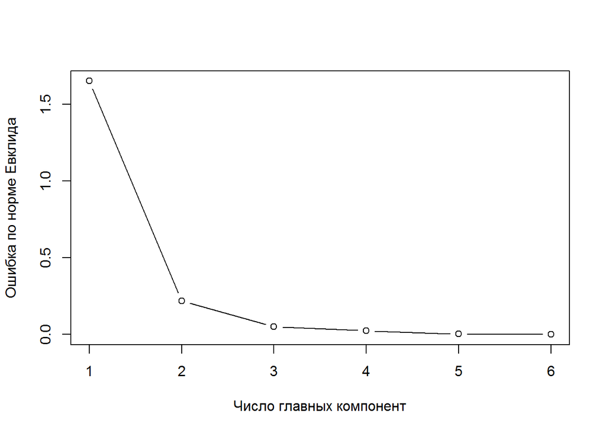

```r
#Ошибка аппроксимации в норме Евклида
plot(x = 1:length(err2),
      y = err2,
      xlab = "Число главных компонент",
      ylab = "Ошибка по норме Евклида",
      type = "b")
```

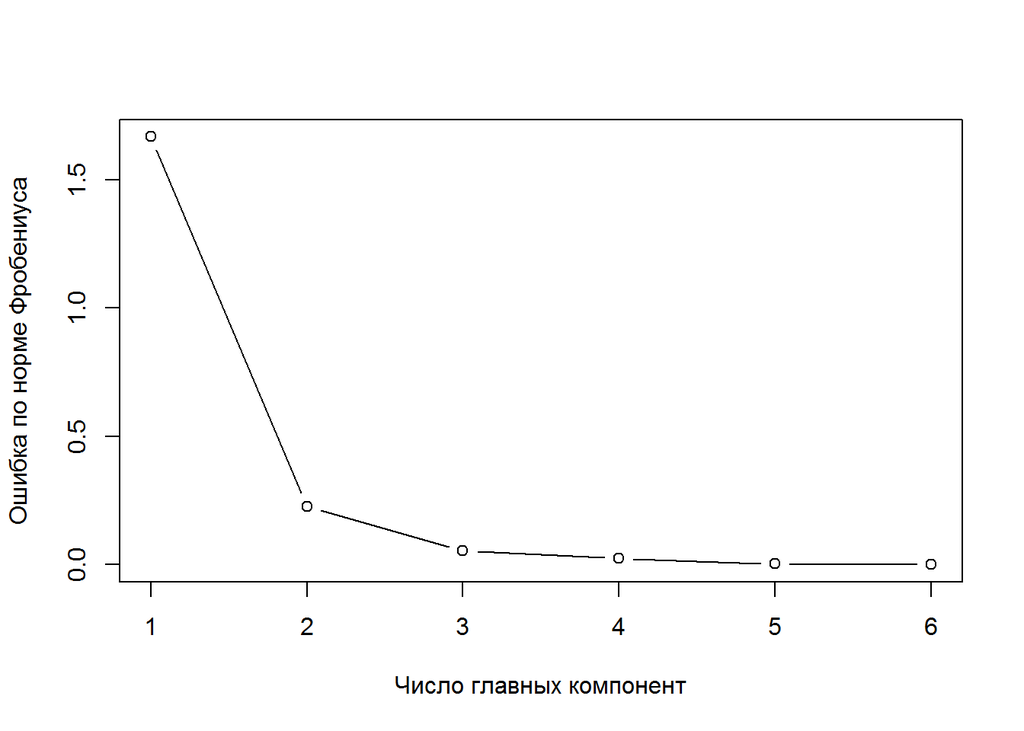

```r
#Ошибка аппроксимации в норме Фробениуса
plot(x = 1:length(errF),
      y = errF,
      xlab = "Число главных компонент",
      ylab = "Ошибка по норме Фробениуса",
      type = "b")
```

Определим количество главных факторов:

- по графику (видно, что график начинает плавно убывать после 2 главного фактора, следовательно главных факторов 2)
- по доле объясненной вариации 99% информации объясняется первыми двумя факторами

```r
#Главные факторы
k<-2
```

## Задание 10

**Выделить главные факторы. Выделить матрицу нагрузок для главных факторов.**

```r
#Главные факторы
MF<-U_svd[ ,1:k]
#Матрица нагрузок для главных факторов
L<-V_svd[ ,1:k] %*% t(S_svd[1:k,1:k])
L
```

```
##            [,1]      [,2]
## [1,]  0.5211114 0.8483691
## [2,]  0.1184725 0.9771768
## [3,] -0.9529477 0.3021929
## [4,]  0.6108909 0.7863778
## [5,] -0.8981340 0.4381145
## [6,] -0.9214723 0.3872008
```

## Задание 11

**Заменить значения исходных признаков линейными комбинациями главных факторов. Оценить погрешность аппроксимации в $l_2$ норме и норме Фробениуса.**

```r
L_tr<-t(L)
L_tr
```

```
##           [,1]      [,2]       [,3]      [,4]       [,5]       [,6]
## [1,] 0.5211114 0.1184725 -0.9529477 0.6108909 -0.8981340 -0.9214723
## [2,] 0.8483691 0.9771768  0.3021929 0.7863778  0.4381145  0.3872008
```

Линейные комбинации главных факторов по каждому признаку:  
$Z_1 = 0.52 \cdot U_1 + 0.85 \cdot U_2$  
$Z_2 = 0.12 \cdot U_1 + 0.98 \cdot U_2$  
$Z_3 = -0.95 \cdot U_1 + 0.3 \cdot U_2$  
$Z_4 = 0.61 \cdot U_1 + 0.79 \cdot U_2$  
$Z_5 = -0.9 \cdot U_1 + 0.44 \cdot U_2$  
$Z_6 = -0.92 \cdot U_1 + 0.39 \cdot U_2$  
Из этого можно сделать вывод, что

- 1 фактор объясняет 3, 5 и 6 признаки;
- 2 фактор объясняет 1, 2 и 4 признаки.

```r
#Погрешность аппроксимации в норме Фробениуса
```

Вычислим погрешность аппроксимации в норме Фробениуса по каждому фактору. Для этого найдем норму Фробениуса матрицы (значение $A$), затем $A_k = ||A - A_k^*||_F = \sqrt{σ_{k+1}^2 + ... + σ_{m}^2}$.

```r
sv<-Z_svd$d
A<-sqrt(sum(sv^2))
for(i in 2:6){
  A2<-sqrt(sum(sv[i:6]^2))
  A2<-A2/A*100
  print(A2)
}
```

```
## [1] 68.0362
## [1] 9.234922
## [1] 2.231676
## [1] 0.9748341
## [1] 0.1048981
```

```r
#Погрешность аппроксимации в Евклидовой норме
```

Вычислим погрешность аппроксимации в Евклидовой норме по каждому фактору. Для этого:

- найдем собственные значения матрицы $S^T \cdot S$ (вектор $N$)
- найдем максимальное собственное значение этой матрицы ($m$)
- найдем Евклидову норму матрицы (значение $B$)
- затем $B_k = ||B - B_k^*||_2 = σ_{k+1}$

```r
N<-eigen(t(S)%*%S)
m<-max(N$values)
B<-sqrt(m)
for(i in 2:6){
  B2<-S[i,i]
  B2<-B2/B*100
  print(B2)
}
```

```
## [1] 91.97532
## [1] 12.22746
## [1] 2.739215
## [1] 1.322425
## [1] 0.1431324
```

## Задание 12

**Предложите и обоснуйте интерпретацию скрытых признаков или покажите, что этого нельзя сделать.**  
1 фактор - финансовое положение (доход, оценка автомобиля заемщика, размер кредита)  
2 фактор - социальный статус (возраст, количество иждивенцев, срок проживания в регионе)